# IODS course project

Mikko Hänninen

# Introduction to Open Data Science - Course Project

# About the project

I first noticed this course from our doctoral student mailing list and thought it sounded interesting. I think Open Data and Open Science are both important aspects of good modern research, which is why I enrolled to this course to learn more about them. Additionally, I hadn’t used R or RStudio let alone GitHub before this course, so I thought I could also learn to use these useful tools as well. So far this course has seemed very well organized, looking forward to learning more!

## Reflecting on my learning experience

I thought that the **R health for Data Science** book together with the **Exercise Set 1** were an excellent way to introduce us to basics of RStudio quickly and clearly. I especially liked using the exercise set, because it gave a nice visual after first reading about the different tools and commands first in the book. I don’t know if there was a certain topic that was more difficult than others, rather I found it to be more of learning the logic of R and use it for your own purposes.

```r
# This is a so-called "R chunk" where you can write R code.

date()
```

```
## [1] "Tue Nov 29 01:14:06 2022"
```

Click [here](https://github.com/mihanninen/IODS-project) to see my GitHub repository.

# Assignment 2

*Describe the work you have done this week and summarize your learning.*

- Describe your work and results clearly.
- Assume the reader has an introductory course level understanding of writing and reading R code as well as statistical methods.
- Assume the reader has no previous knowledge of your data or the more advanced methods you are using.

```r
date()
```

```
## [1] "Tue Nov 29 01:14:06 2022"
```

## 1. Part

The data I’m using in my analysis is derived from the larger “JYTOPKYS2”-dataset. This dataset was collected from a survey to statistics students, that was used to evaluate to effects of learning approaches to exam results.

Seven variables from the original dataset were chosen for this data (gender, age, attitude, deep learning, strategic learning, surface learning and exam points). Additionally, students who scored 0 in their exam were excluded from this data.

The variable `attitude` in `learning2014` is a sum of 10 questions related to students attitude towards statistics, each measured on the [Likert scale](https://en.wikipedia.org/wiki/Likert_scale) (1-5).

Variables `deep` (deep learning), `stra`(strategic learning) and `surf`(surface learning) in `learning2014` are the mean values from the combinations of questions that relate to each learning approach, respectively. Each question was once again measured on the Likert scale (1-5).

In the following R chunk I will explore the structure and dimensions of the data further.

```r
# reading the data into memory
learning2014 <- read.csv("~/Documents/Tohtoritutkinto/Open Science/IODS-project/data/learning2014.csv", sep = ",", header = TRUE)

#displaying dataframe
learning2014
```

```
##     gender age attitude     deep  stra     surf points
## 1        F  53       37 3.583333 3.375 2.583333     25
## 2        M  55       31 2.916667 2.750 3.166667     12
## 3        F  49       25 3.500000 3.625 2.250000     24
## 4        M  53       35 3.500000 3.125 2.250000     10
## 5        M  49       37 3.666667 3.625 2.833333     22
## 6        F  38       38 4.750000 3.625 2.416667     21
## 7        M  50       35 3.833333 2.250 1.916667     21
## 8        F  37       29 3.250000 4.000 2.833333     31
## 9        M  37       38 4.333333 4.250 2.166667     24
## 10       F  42       21 4.000000 3.500 3.000000     26
## 11       M  37       39 3.583333 3.625 2.666667     31
## 12       F  34       38 3.833333 4.750 2.416667     31
## 13       F  34       24 4.250000 3.625 2.250000     23
## 14       F  34       30 3.333333 3.500 2.750000     25
```

[output cut: 152 more lines]

```r
# the dataset has 166 rows and 7 columns
dim(learning2014)
```

```
## [1] 166   7
```

```r
# there are 7 variables and 166 observations. One variable is a character string, while the other variables are integers or numbers
str(learning2014)
```

```
## 'data.frame':    166 obs. of  7 variables:
##  $ gender  : chr  "F" "M" "F" "M" ...
##  $ age     : int  53 55 49 53 49 38 50 37 37 42 ...
##  $ attitude: int  37 31 25 35 37 38 35 29 38 21 ...
##  $ deep    : num  3.58 2.92 3.5 3.5 3.67 ...
##  $ stra    : num  3.38 2.75 3.62 3.12 3.62 ...
##  $ surf    : num  2.58 3.17 2.25 2.25 2.83 ...
##  $ points  : int  25 12 24 10 22 21 21 31 24 26 ...
```

```r
# a summary of the variables
summary(learning2014)
```

```
##     gender               age           attitude          deep
##  Length:166         Min.   :17.00   Min.   :14.00   Min.   :1.583
##  Class :character   1st Qu.:21.00   1st Qu.:26.00   1st Qu.:3.333
##  Mode  :character   Median :22.00   Median :32.00   Median :3.667
##                     Mean   :25.51   Mean   :31.43   Mean   :3.680
##                     3rd Qu.:27.00   3rd Qu.:37.00   3rd Qu.:4.083
##                     Max.   :55.00   Max.   :50.00   Max.   :4.917
##       stra            surf           points
##  Min.   :1.250   Min.   :1.583   Min.   : 7.00
##  1st Qu.:2.625   1st Qu.:2.417   1st Qu.:19.00
##  Median :3.188   Median :2.833   Median :23.00
##  Mean   :3.121   Mean   :2.787   Mean   :22.72
##  3rd Qu.:3.625   3rd Qu.:3.167   3rd Qu.:27.75
##  Max.   :5.000   Max.   :4.333   Max.   :33.00
```

## 2. Part

Here I present a graphical overview of the data and show summaries of the variables in the data.

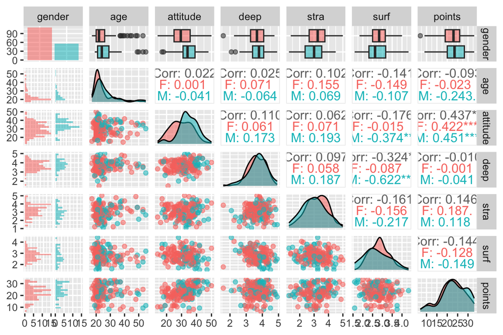

```r
# accessing the GGally and ggplot2 libraries
library(GGally)
library(ggplot2)

# creating a plot matrix to give a graphical overview of the data
p <- ggpairs(learning2014, mapping = aes(col = gender, alpha = 0.3), lower = list(combo = wrap("facethist", bins = 20)))

# drawing the plot
p
```

```r
# creating summaries of the variables
summary(factor(learning2014$gender))
```

```
##   F   M
## 110  56
```

```r
summary(learning2014$age)
```

```
##    Min. 1st Qu.  Median    Mean 3rd Qu.    Max.
##   17.00   21.00   22.00   25.51   27.00   55.00
```

```r
summary(learning2014$attitude)
```

```
##    Min. 1st Qu.  Median    Mean 3rd Qu.    Max.
##   14.00   26.00   32.00   31.43   37.00   50.00
```

```r
summary(learning2014$deep)
```

```
##    Min. 1st Qu.  Median    Mean 3rd Qu.    Max.
##   1.583   3.333   3.667   3.680   4.083   4.917
```

```r
summary(learning2014$stra)
```

```
##    Min. 1st Qu.  Median    Mean 3rd Qu.    Max.
##   1.250   2.625   3.188   3.121   3.625   5.000
```

```r
summary(learning2014$surf)
```

```
##    Min. 1st Qu.  Median    Mean 3rd Qu.    Max.
##   1.583   2.417   2.833   2.787   3.167   4.333
```

```r
summary(learning2014$points)
```

```
##    Min. 1st Qu.  Median    Mean 3rd Qu.    Max.
##    7.00   19.00   23.00   22.72   27.75   33.00
```

The data is divided in the plot matrix by gender, with females depicted by the color red and males by the color green. Looking at the distributions of variables in the graphical overview, you can quickly notice that the `age`-variable is strongly skewed to the right. This is expected as the study population consists of students. We also notice a slight left skew in deep learning (`deep`) and the `points`-variable. The `attitude`-variable is slightly left skewed in males, but almost normal distribution in females. Additionally, suface learning (`surf`) is right skewed in males, but again closer to normal distribution in females.

We can further appreciate the distributions and characteristics of individual variables by looking at the scatter and box plots of the plot matrix. For example, you could inspect if a certain variable has lots of outliers in the box plot or if spread is larger or different in the scatter plot.

The graphical overview also shows correlation coefficients between variables. The most notable of these is the strong positive correlation between `attitude` and `points`. Also worth noting is the strong negative correlation between surface learning (`surf`) and both `attitude`and deep learning (`deep`) in male students that is absent in female students. There is also a significant negative correlation between surface learning (`surf`) and strategic learning (`stra`) when the students are analyzied overall.

Looking at the summaries of the variables, you notice that the median age is quite young (median = 22 years) and that there are almost twice as many females as there are men (110 females to 56 males).

## 3. Part

Here I create a regression model where exam points is the target variable.

```r
# accessing the GGally and ggplot2 libraries
library(GGally)
library(ggplot2)

# creating a regression model with multiple explanatory variables
my_model <- lm(points ~ attitude + stra + surf, data = learning2014)

summary(my_model)
```

```
##
## Call:
## lm(formula = points ~ attitude + stra + surf, data = learning2014)
##
## Residuals:
##      Min       1Q   Median       3Q      Max
## -17.1550  -3.4346   0.5156   3.6401  10.8952
##
## Coefficients:
##             Estimate Std. Error t value Pr(>|t|)
## (Intercept) 11.01711    3.68375   2.991  0.00322 **
## attitude     0.33952    0.05741   5.913 1.93e-08 ***
## stra         0.85313    0.54159   1.575  0.11716
## surf        -0.58607    0.80138  -0.731  0.46563
## ---
## Signif. codes:  0 '***' 0.001 '**' 0.01 '*' 0.05 '.' 0.1 ' ' 1
##
## Residual standard error: 5.296 on 162 degrees of freedom
## Multiple R-squared:  0.2074, Adjusted R-squared:  0.1927
## F-statistic: 14.13 on 3 and 162 DF,  p-value: 3.156e-08
```

```r
# creating new model without non-significant explanatory variable surf
my_model2 <- lm(points ~ attitude + stra, data = learning2014)
summary(my_model2)
```

```
##
## Call:
## lm(formula = points ~ attitude + stra, data = learning2014)
##
## Residuals:
##      Min       1Q   Median       3Q      Max
## -17.6436  -3.3113   0.5575   3.7928  10.9295
##
## Coefficients:
##             Estimate Std. Error t value Pr(>|t|)
## (Intercept)  8.97290    2.39591   3.745  0.00025 ***
## attitude     0.34658    0.05652   6.132 6.31e-09 ***
## stra         0.91365    0.53447   1.709  0.08927 .
## ---
## Signif. codes:  0 '***' 0.001 '**' 0.01 '*' 0.05 '.' 0.1 ' ' 1
##
## Residual standard error: 5.289 on 163 degrees of freedom
## Multiple R-squared:  0.2048, Adjusted R-squared:  0.1951
## F-statistic: 20.99 on 2 and 163 DF,  p-value: 7.734e-09
```

After the first model, I removed the `surf`variable from the model since it didn’t have a significant relationship with the target variable `points`. The new model was fitted with only ´attitude`and`stra` as explanatory variables.

## 4. Part

Next I use the summary of my new fitted model and explain the relationship between the chosen explanatory variables and the target variable.

```r
# accessing the GGally and ggplot2 libraries
library(GGally)
library(ggplot2)

# my new model without the non-significant explanatory variable surf and its summary
my_model2 <- lm(points ~ attitude + stra, data = learning2014)
summary(my_model2)
```

```
##
## Call:
## lm(formula = points ~ attitude + stra, data = learning2014)
##
## Residuals:
##      Min       1Q   Median       3Q      Max
## -17.6436  -3.3113   0.5575   3.7928  10.9295
##
## Coefficients:
##             Estimate Std. Error t value Pr(>|t|)
## (Intercept)  8.97290    2.39591   3.745  0.00025 ***
## attitude     0.34658    0.05652   6.132 6.31e-09 ***
## stra         0.91365    0.53447   1.709  0.08927 .
## ---
## Signif. codes:  0 '***' 0.001 '**' 0.01 '*' 0.05 '.' 0.1 ' ' 1
##
## Residual standard error: 5.289 on 163 degrees of freedom
## Multiple R-squared:  0.2048, Adjusted R-squared:  0.1951
## F-statistic: 20.99 on 2 and 163 DF,  p-value: 7.734e-09
```

In my new model we notice that both attitude and strategic learning have still positive estimates (0.34658 and 0.91365 respectively). This means that for every point the `attitude`-variable increases, the exam points increase 0.34658 on average (and 0.91365 in the case of `stra`). The t-statistics of attitude is clearly above 0 (t-value: 6.132), meaning there is a high possibility that we can declare a relationship between `points` and `attitude`. This is supported by the small Pr(>|t|) in `attribute` (Pr(>|t|): 6.31e-09), meaning there is a very small chance of seeing a relationship between `points` and `attitude` due to chance. Even though the t-statistics of `stra` is also clearly above 0 (t-value: 1.709) and the Pr(>|t|) is smaller than before (Pr(>|t|): 0.08927), it still falls short of the default cut-off point of p <0.05. Therefore, we cannot say that there is a significant relationship between `points`and `stra`. Rather there is strong evidence of a potential relationship, but there is approximately an 8,9% probability that this is due to chance.

## 5. Part

Finally I produce the following diagnostic plots of my model: Residuals vs Fitted values, Normal QQ-plot and Residuals vs Leverage.

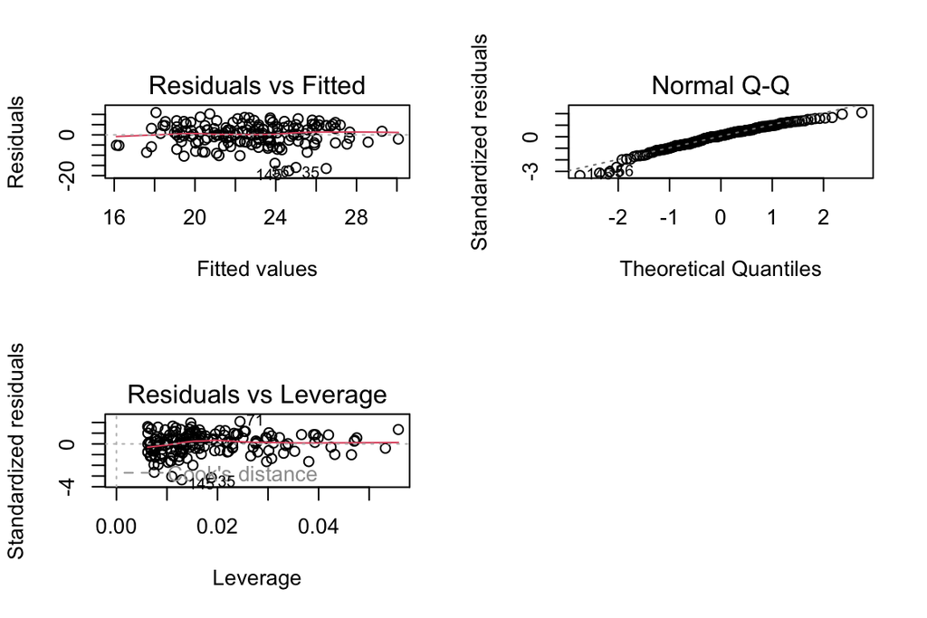

```r
# divides the window into a 2x2 grid
par(mfrow = c(2,2))

# draws the diagnostic plots using the plot() function. The previously specified plots 1, 2 and 5 are selected
plot(my_model2, c(1,2,5))
```

Linear regression has four main assumptions: linear relationship, independence, homoscedasticity and normality.

We can use the residuals vs. fitted plot to evaluate if the there is correlation between residuals and fitted values. As we can see, the datapoints have a fairly random distribution around the 0 line, which supports the hypothesis that it is linear and the data is reasonably homoscedastic. There are a few outliers with large negative residuals, but these don’t appear to alter the overall variance in the data.

Using the normal Q-Q plot, we can evaluate the skewness of data and fit of model. My model seems to be slightly skewed left, but is fairly normally distributed overall.

Finally, we can use the residuals vs. leverage plot to assess linearity and influential points. Influential points are observations, that when removed from the dataset could change the coefficients of the model when fitting again. Here we can see that the the spread is nicely linear. No influentials points are observed in the spread.

# Assignment 3 - Logistic regression

```r
date()
```

```
## [1] "Tue Nov 29 01:14:10 2022"
```

## Reading joined student alcohol consumption data

The data we are using in this assignment was acquired from the UCI Machine Learning Repository, Student Performance Data (incl. Alcohol consumption) [page](https://archive.ics.uci.edu/ml/datasets/Student+Performance) and later modified.

```r
#install required packages if needed
#install.packages("tidyverse")
#install.packages("boot")
#installed.packages("tidyr")
#install.packages("readr")
#install.packages("dplyr")
#install.packages("patchwork")

# access the readr and dplyr library
library(readr)
library(dplyr)
#read the 'alc' data set into memory
alc <- read_csv("~/Documents/Tohtoritutkinto/Open Science/IODS-project/data/alc.csv", show_col_types=FALSE)

# look at the column names/names of the variables of the data set
colnames(alc)
```

```
##  [1] "school"     "sex"        "age"        "address"    "famsize"
##  [6] "Pstatus"    "Medu"       "Fedu"       "Mjob"       "Fjob"
## [11] "reason"     "guardian"   "traveltime" "studytime"  "schoolsup"
## [16] "famsup"     "activities" "nursery"    "higher"     "internet"
## [21] "romantic"   "famrel"     "freetime"   "goout"      "Dalc"
## [26] "Walc"       "health"     "failures"   "paid"       "absences"
## [31] "G1"         "G2"         "G3"         "alc_use"    "high_use"
```

The data was collected from students in secondary education of two Portuguese schools. The data attributes include student grades, demographic, social and school related features) and it was collected by using school reports and questionnaires. As we can see, there are 35 variables in our data set. Our focus in this assignment is to evaluate the possible relationship between high/low alcohol use (`high_use`) and other variables.

## Choosing variables in relation to high/low alcohol consumption

I chose student’s sex (`sex`), going out with friends (`goout`), number of past class failures (`failures`) and number of schools absences (`absences`) as my variables of interest. My hypothesis is that male students have on average a higher consumption of alcohol when compared to female students, as males have also higher alcohol consumption in the general population. I also hypothesize that students with more absences and class failures have higher alcohol consumption on average, as people with excessive alcohol might miss work due to hangovers etc. Additionally, I hypothesize that going out with friends more often increases risk of alcohol consumption as alcohol tends to be frequent component when young adults socialize.

## Exploring the chosen variables

```r
# access tidyr library
library(tidyr)

# produce summary statistics by group
alc %>% group_by(sex, high_use) %>% summarise(count = n(), mean_going_out = mean(goout), mean_failures = mean(failures), mean_absences = mean(absences))
```

[output not shown]

```
## # A tibble: 4 × 6
## # Groups:   sex [2]
##   sex   high_use count mean_going_out mean_failures mean_absences
##   <chr> <lgl>    <int>          <dbl>         <dbl>         <dbl>
## 1 F     FALSE      154           2.95         0.104          4.25
## 2 F     TRUE        41           3.39         0.293          6.85
## 3 M     FALSE      105           2.70         0.143          2.91
## 4 M     TRUE        70           3.93         0.386          6.1
```

Looking at our summarised table, we can see that there are several more males that have high alcohol consumption rates when compared to females (70 and 41, respectively), even though there are almost the same amount of males and females in total (175 and 195, respectively). We can also make note that students with high alcohol consumption go out with their friends more often than those students that don’t have high alcohol consumption, regardless of sex. Additionally, we can also notice that the average number of class failures and school absences are higher with students with high alcohol consumption than others regardless of sex.

```r
# access ggplot2 and patchwork libraries
library(ggplot2)
library(patchwork)
theme_set(theme_classic())

# closer look at the distribution of failures and goout
alc %>% count(failures)
```

```
## # A tibble: 4 × 2
##   failures     n
##      <dbl> <int>
## 1        0   325
## 2        1    24
## 3        2    17
## 4        3     4
```

```r
alc %>% count(goout)
```

```
## # A tibble: 5 × 2
##   goout     n
##   <dbl> <int>
## 1     1    22
## 2     2    97
## 3     3   120
## 4     4    78
## 5     5    53
```

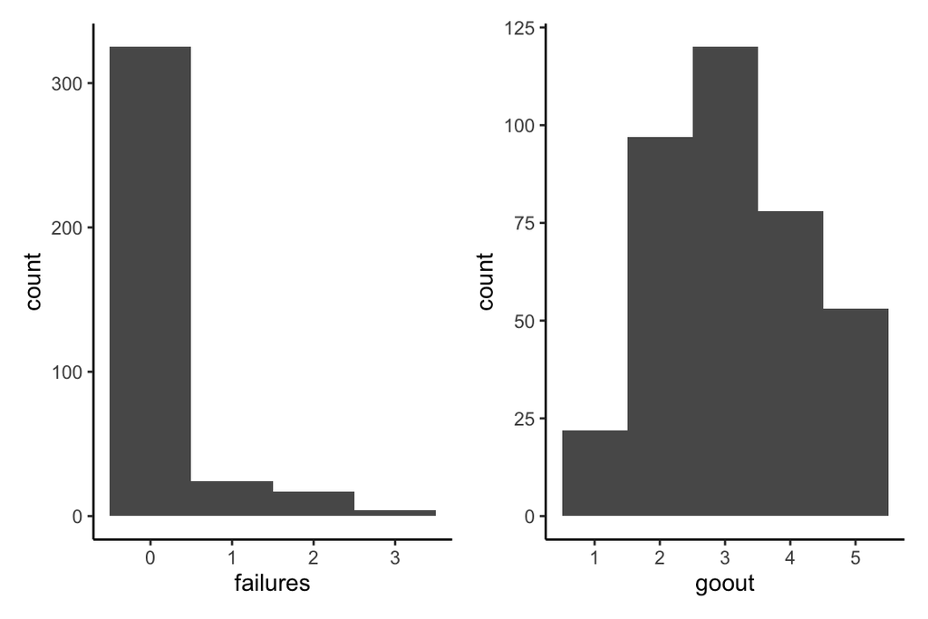

```r
# create histograms for failures and goout
h1 <- alc %>% ggplot(aes(x = failures)) + geom_histogram(binwidth = 1) + scale_fill_grey()
h2 <- alc %>% ggplot(aes(x = goout)) + geom_histogram(binwidth = 1) + scale_fill_grey()

# draw histograms of failures and goout
h1 + h2
```

As we can see from the tables and histograms, class failures are heavily skewed right as the vast majority of students haven’t failed any class and only a handful of students have failed at least one class (325 and 45, respectively). Going out with friends has almost a normal distribution, although only a few students go out with their friends very little.

Next we will look at the chosen variables together with their relationship with alcohol consumption.

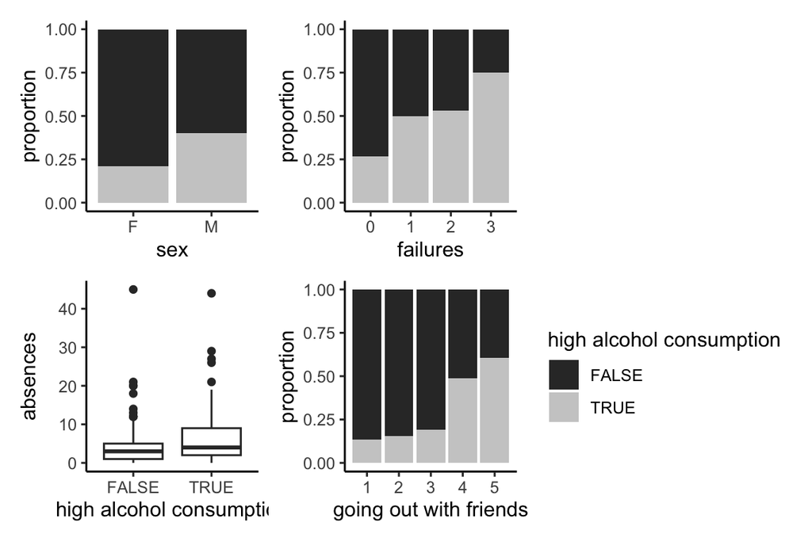

```r
# define the plot as a bar plot
g1 <- alc %>% ggplot(aes(x = sex, fill = high_use)) + geom_bar(position = "fill") + ylab("proportion") + theme(legend.position = "none") + scale_fill_grey()

# define the plot as a bar plot
g2 <- alc %>% ggplot(aes(x = failures, fill = high_use)) + geom_bar(position = "fill") + ylab("proportion") + theme(legend.position = "none") + scale_fill_grey()

# define the plot as a box plot
g3 <- alc %>% ggplot(aes(x = high_use, y = absences)) + geom_boxplot() + xlab("high alcohol consumption")

# define the plot as a bar plot
g4 <- alc %>% ggplot(aes(x = goout, fill = high_use)) + geom_bar(position = "fill") + ylab("proportion") + xlab("going out with friends") + scale_fill_grey(name = "high alcohol consumption")

# draw the plots
g1 + g2 + g3 + g4
```

Looking first at the `sex` variable, we notice that a higher proportion of males have high alcohol consumption compared to women as we also noted previously.

Next looking at the `failures` variable, we notice that the proportion of students with high alcohol consumption increases with the number of failed classes, which suggests a positive correlation between them.

Next looking at the `absences` variable, we notice that the median absences and spread seems to be larger with students with high alcohol consumption. This might also point to positive correlation between them.

The findings in these plots seem to support my initial hypothesis regarding these chosen variables.

## Creating a logistic regression model using the selected variables

Next I created a logistic regression model to predict high/low alcohol consumption. The target value is `high_use` and the explanatory variables are `failures`, `absences`, `sex` and `goout`. Here i provide a summary of my model and interpret the coefficients in my model as odds ratios.

```r
# create logistic regression model using selected variables
m <- glm(high_use ~ failures + absences + sex + goout, data = alc, family = "binomial")

# print out a summary of the model
summary(m)
```

```
##
## Call:
## glm(formula = high_use ~ failures + absences + sex + goout, family = "binomial",
##     data = alc)
##
## Deviance Residuals:
##     Min       1Q   Median       3Q      Max
## -2.1521  -0.7929  -0.5317   0.7412   2.3706
##
## Coefficients:
##             Estimate Std. Error z value Pr(>|z|)
## (Intercept) -4.14389    0.47881  -8.654  < 2e-16 ***
## failures     0.48932    0.23073   2.121 0.033938 *
## absences     0.08246    0.02266   3.639 0.000274 ***
## sexM         0.97989    0.26156   3.746 0.000179 ***
## goout        0.69801    0.12093   5.772 7.83e-09 ***
## ---
## Signif. codes:  0 '***' 0.001 '**' 0.01 '*' 0.05 '.' 0.1 ' ' 1
##
## (Dispersion parameter for binomial family taken to be 1)
##
##     Null deviance: 452.04  on 369  degrees of freedom
## Residual deviance: 369.50  on 365  degrees of freedom
## AIC: 379.5
##
## Number of Fisher Scoring iterations: 4
```

```r
# compute odds ratios (OR) for the coefficients of the model by exponentiation
OR <- coef(m) %>% exp

# compute confidence intervals (CI) for the odds ratios by exponentiation
CI <- confint(m) %>% exp
# print out the odds ratios with their confidence intervals
cbind(OR, CI)
```

```
##                     OR       2.5 %     97.5 %
## (Intercept) 0.01586098 0.005950831 0.03905075
## failures    1.63121360 1.042981792 2.59042892
## absences    1.08595465 1.039999394 1.13814475
## sexM        2.66415000 1.605059602 4.48576247
## goout       2.00975350 1.594527456 2.56461657
```

All the explanatory variables have a positive regression coefficient, which means that the variables increase the probability of high consumption of alcohol. The z-value is the regression coefficient divided by the standard error. If it is clearly above or below 0, then it is likely that it is significant variable. Usually the cut-off value used for significance is 2.0 (which corresponds to p <0.05), which is met by all my chosen variables. We can see that `failures` has a significant relationship with `high_use` and the other chosen variables have very strongly significant relationships with `high_use`.

Looking at the odds ratios of my explanatory variables, we see that there is a strong positive association between the variables ``goout` and `sex` and `high_use` as both the OR and CI are clearly above 1.0. In addition, the variables `failures` and `absences` have also a positive association with `high_use` although their increase in probability of high alcohol consumption is not as large as with `goout` and `sex`.

Next we explore the predictive power of my model.

```r
# predict() the probability of high_use
probabilities <- predict(m, type = "response")

# add the predicted probabilities to 'alc'
alc <- mutate(alc, probability = probabilities)

# use the probabilities to make a prediction of high_use
alc <- mutate(alc, prediction = probability > 0.5)

# tabulate the target variable versus the predictions
table(high_use = alc$high_use, prediction = alc$prediction)
```

```
##         prediction
## high_use FALSE TRUE
##    FALSE   243   16
##    TRUE     61   50
```

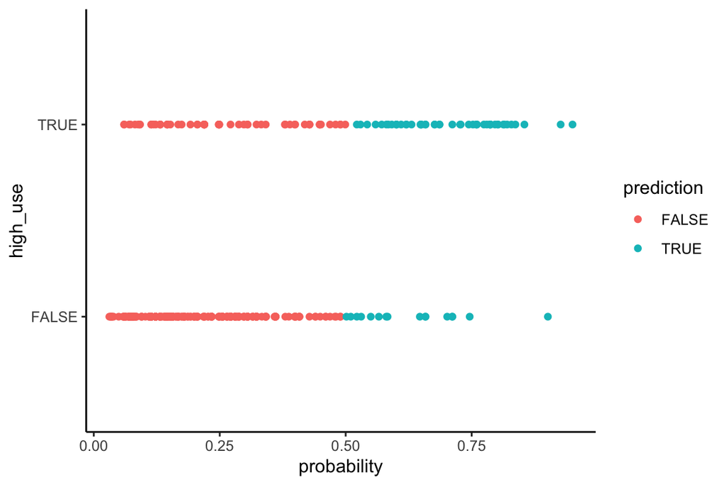

```r
# initialize a plot of 'high_use' versus 'probability' in 'alc'
g <- ggplot(alc, aes(x = probability, y = high_use, col = prediction))

# define the geom as points and draw the plot
g + geom_point()
```

```r
# tabulate the target variable versus the predictions
table(high_use = alc$high_use, prediction = alc$prediction) %>% prop.table() %>% addmargins()
```

```
##         prediction
## high_use      FALSE       TRUE        Sum
##    FALSE 0.65675676 0.04324324 0.70000000
##    TRUE  0.16486486 0.13513514 0.30000000
##    Sum   0.82162162 0.17837838 1.00000000
```

```r
# computing the total proportion of inaccurately classified individuals ( = training error)
(16+61)/370
```

```
## [1] 0.2081081
```

From the cross tabulation we can see that our model is fairly good at predicting low consumption of alcohol, but not as good when alcohol consumption is high (243/259 and 50/111, respectively). This is made clearer by looking at the point plot.

The training error of my model was about 0.21.

Assuming a person just simply guesses by random if the alcohol consumption of a student is high or low, then it is likely that the training error of this guessing would approach 0.50 (flipping a coin). This would mean my model is able to classify approximately 30% more of students correctly than by simply guessing.

## Bonus: Performing 10-fold cross validation of my model

As an additional task we were asked to perform a 10-fold cross validation of our models.

```r
# define a loss function (mean prediction error)
loss_func <- function(class, prob) {
  n_wrong <- abs(class - prob) > 0.5
  mean(n_wrong)
}

# 10-fold cross-validation
library(boot)
cv <- cv.glm(data = alc, cost = loss_func, glmfit = m, K = 10)

# average number of wrong predictions in the cross validation
cv$delta[1]
```

```
## [1] 0.2054054
```

As we can see, my model has a prediction error of about 0.21, which is better than the model introduced in the Exercise Set 3 (prediction error ≈ 0,26).

# Assignment 4 - Clustering and classification

```r
date()
```

```
## [1] "Tue Nov 29 01:14:11 2022"
```

```r
# install.packages(c("MASS", "corrplot", "tidyverse", "reshape2")) if needed
```

## Exploring our data

In this assignment we look at the `Boston` data set from the `MASS` library. It describes housing values in suburbs of Boston and various other factors relating to the housings and locations. The data frame has 14 variables and 506 observations (14 columns and 506 rows). Here I show the structure of the data frame and a short summary of the variables in question.

```r
# access the MASS package
library(MASS)
# load the Boston data
data("Boston")

# explore the dataset
str(Boston)
```

```
## 'data.frame':    506 obs. of  14 variables:
##  $ crim   : num  0.00632 0.02731 0.02729 0.03237 0.06905 ...
##  $ zn     : num  18 0 0 0 0 0 12.5 12.5 12.5 12.5 ...
##  $ indus  : num  2.31 7.07 7.07 2.18 2.18 2.18 7.87 7.87 7.87 7.87 ...
##  $ chas   : int  0 0 0 0 0 0 0 0 0 0 ...
##  $ nox    : num  0.538 0.469 0.469 0.458 0.458 0.458 0.524 0.524 0.524 0.524 ...
##  $ rm     : num  6.58 6.42 7.18 7 7.15 ...
##  $ age    : num  65.2 78.9 61.1 45.8 54.2 58.7 66.6 96.1 100 85.9 ...
##  $ dis    : num  4.09 4.97 4.97 6.06 6.06 ...
##  $ rad    : int  1 2 2 3 3 3 5 5 5 5 ...
##  $ tax    : num  296 242 242 222 222 222 311 311 311 311 ...
##  $ ptratio: num  15.3 17.8 17.8 18.7 18.7 18.7 15.2 15.2 15.2 15.2 ...
##  $ black  : num  397 397 393 395 397 ...
##  $ lstat  : num  4.98 9.14 4.03 2.94 5.33 ...
##  $ medv   : num  24 21.6 34.7 33.4 36.2 28.7 22.9 27.1 16.5 18.9 ...
```

```r
summary(Boston)
```

```
##       crim                zn             indus            chas
##  Min.   : 0.00632   Min.   :  0.00   Min.   : 0.46   Min.   :0.00000
##  1st Qu.: 0.08205   1st Qu.:  0.00   1st Qu.: 5.19   1st Qu.:0.00000
##  Median : 0.25651   Median :  0.00   Median : 9.69   Median :0.00000
##  Mean   : 3.61352   Mean   : 11.36   Mean   :11.14   Mean   :0.06917
##  3rd Qu.: 3.67708   3rd Qu.: 12.50   3rd Qu.:18.10   3rd Qu.:0.00000
##  Max.   :88.97620   Max.   :100.00   Max.   :27.74   Max.   :1.00000
##       nox               rm             age              dis
##  Min.   :0.3850   Min.   :3.561   Min.   :  2.90   Min.   : 1.130
##  1st Qu.:0.4490   1st Qu.:5.886   1st Qu.: 45.02   1st Qu.: 2.100
##  Median :0.5380   Median :6.208   Median : 77.50   Median : 3.207
##  Mean   :0.5547   Mean   :6.285   Mean   : 68.57   Mean   : 3.795
##  3rd Qu.:0.6240   3rd Qu.:6.623   3rd Qu.: 94.08   3rd Qu.: 5.188
##  Max.   :0.8710   Max.   :8.780   Max.   :100.00   Max.   :12.127
##       rad              tax           ptratio          black
##  Min.   : 1.000   Min.   :187.0   Min.   :12.60   Min.   :  0.32
##  1st Qu.: 4.000   1st Qu.:279.0   1st Qu.:17.40   1st Qu.:375.38
##  Median : 5.000   Median :330.0   Median :19.05   Median :391.44
##  Mean   : 9.549   Mean   :408.2   Mean   :18.46   Mean   :356.67
##  3rd Qu.:24.000   3rd Qu.:666.0   3rd Qu.:20.20   3rd Qu.:396.23
##  Max.   :24.000   Max.   :711.0   Max.   :22.00   Max.   :396.90
##      lstat            medv
##  Min.   : 1.73   Min.   : 5.00
##  1st Qu.: 6.95   1st Qu.:17.02
##  Median :11.36   Median :21.20
##  Mean   :12.65   Mean   :22.53
##  3rd Qu.:16.95   3rd Qu.:25.00
##  Max.   :37.97   Max.   :50.00
```

## Graphical overview of data

Here I visualize the distribution of the variables and the relationships between them.

```r
# access the required libraries
library(tidyr)
library(reshape2)
```

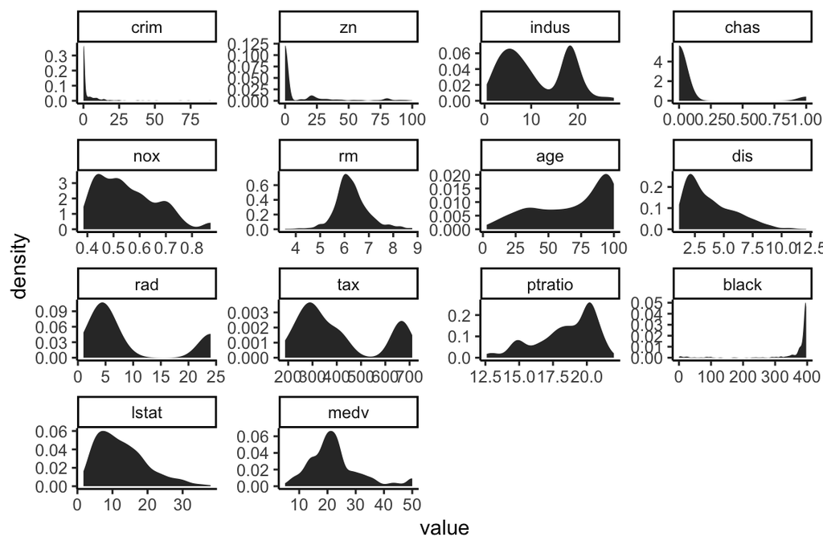

```r
library(ggplot2)
library(corrplot)
# convert data from wide to long
melt.boston <- melt(Boston)
# visualize variables with small multiple chart
g1 <- ggplot(data = melt.boston, aes(x = value)) +
stat_density() +
facet_wrap(~variable, scales = "free")
g1
```

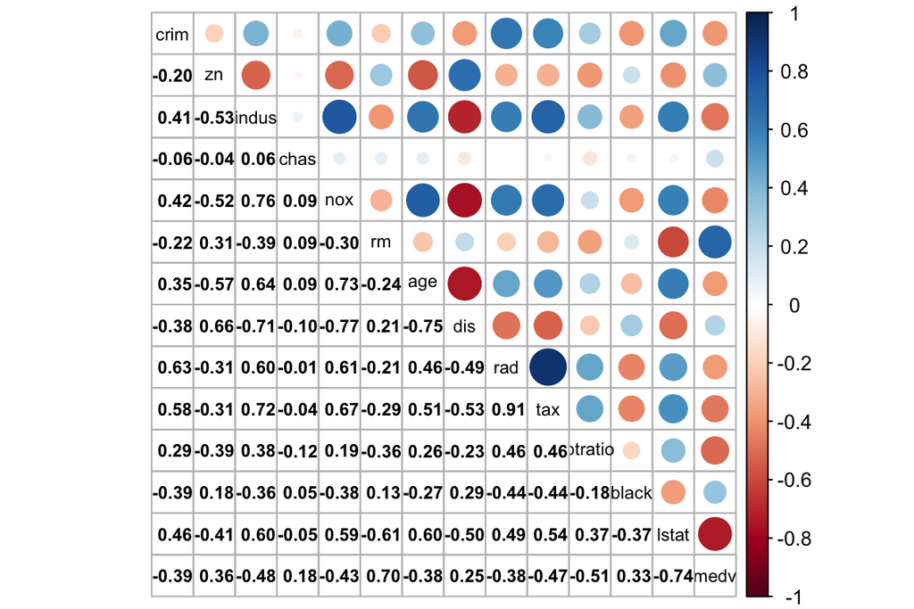

```r
# calculate the correlation matrix and round it
cor_matrix <- cor(Boston) %>% round(2)

# test correlation
testRes = cor.mtest(cor_matrix, conf.level = 0.95)

# visualize the correlation matrix
corrplot.mixed(cor_matrix, tl.col = "black", lower.col = "black", number.cex = 0.7, tl.cex=0.7)
```

## Standardizing the data

In order to standardize our data we have to scale the data.

```r
# center and standardize variables
boston_scaled <- scale(Boston)

# change the object to data frame
boston_scaled <- as.data.frame(boston_scaled)

# print summary of scaled variables
summary(boston_scaled)
```

```
##       crim                 zn               indus              chas
##  Min.   :-0.419367   Min.   :-0.48724   Min.   :-1.5563   Min.   :-0.2723
##  1st Qu.:-0.410563   1st Qu.:-0.48724   1st Qu.:-0.8668   1st Qu.:-0.2723
##  Median :-0.390280   Median :-0.48724   Median :-0.2109   Median :-0.2723
##  Mean   : 0.000000   Mean   : 0.00000   Mean   : 0.0000   Mean   : 0.0000
##  3rd Qu.: 0.007389   3rd Qu.: 0.04872   3rd Qu.: 1.0150   3rd Qu.:-0.2723
##  Max.   : 9.924110   Max.   : 3.80047   Max.   : 2.4202   Max.   : 3.6648
##       nox                rm               age               dis
##  Min.   :-1.4644   Min.   :-3.8764   Min.   :-2.3331   Min.   :-1.2658
##  1st Qu.:-0.9121   1st Qu.:-0.5681   1st Qu.:-0.8366   1st Qu.:-0.8049
##  Median :-0.1441   Median :-0.1084   Median : 0.3171   Median :-0.2790
##  Mean   : 0.0000   Mean   : 0.0000   Mean   : 0.0000   Mean   : 0.0000
##  3rd Qu.: 0.5981   3rd Qu.: 0.4823   3rd Qu.: 0.9059   3rd Qu.: 0.6617
##  Max.   : 2.7296   Max.   : 3.5515   Max.   : 1.1164   Max.   : 3.9566
##       rad               tax             ptratio            black
##  Min.   :-0.9819   Min.   :-1.3127   Min.   :-2.7047   Min.   :-3.9033
##  1st Qu.:-0.6373   1st Qu.:-0.7668   1st Qu.:-0.4876   1st Qu.: 0.2049
##  Median :-0.5225   Median :-0.4642   Median : 0.2746   Median : 0.3808
##  Mean   : 0.0000   Mean   : 0.0000   Mean   : 0.0000   Mean   : 0.0000
##  3rd Qu.: 1.6596   3rd Qu.: 1.5294   3rd Qu.: 0.8058   3rd Qu.: 0.4332
##  Max.   : 1.6596   Max.   : 1.7964   Max.   : 1.6372   Max.   : 0.4406
##      lstat              medv
##  Min.   :-1.5296   Min.   :-1.9063
##  1st Qu.:-0.7986   1st Qu.:-0.5989
##  Median :-0.1811   Median :-0.1449
##  Mean   : 0.0000   Mean   : 0.0000
##  3rd Qu.: 0.6024   3rd Qu.: 0.2683
##  Max.   : 3.5453   Max.   : 2.9865
```

Next we create a categorical variable of the crime rate in the scaled data set. After this, we divide the data set to train and test sets (80% of the data belongs to the train set).

```r
#access the dplyr library
library(dplyr)

# create a quantile vector of crim
bins <- quantile(boston_scaled$crim)

# create a categorical variable 'crime'
crime <- cut(boston_scaled$crim, breaks = bins, include.lowest = TRUE, labels = c("low", "med_low", "med_high", "high"))

# remove original crim from the dataset
boston_scaled <- dplyr::select(boston_scaled, -crim)

# add the new categorical value to scaled data
boston_scaled <- data.frame(boston_scaled, crime)

# number of rows in the Boston dataset
n <- nrow(boston_scaled)

# choose randomly 80% of the rows
ind <- sample(n,  size = n * 0.8)

# create train set
train <- boston_scaled[ind,]

# create test set
test <- boston_scaled[-ind,]
```

## Fitting the linear discriminant analysis

Here we fit a linear discriminant analysis (LDA) on the train set, using the categorical crime rate `crime` as the target variable and all the other variables in the data set as predictor variables. We then visualize this analysis with a biplot.

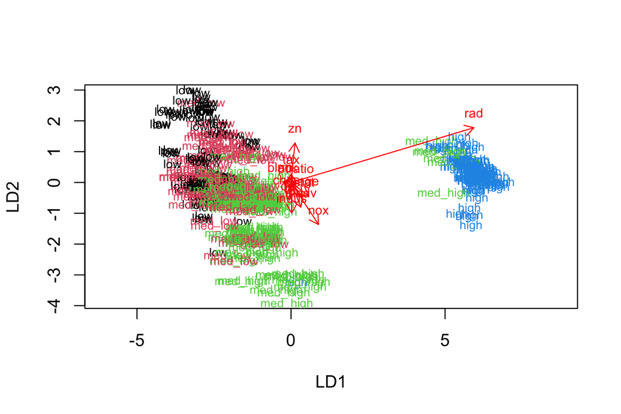

```r
# linear discriminant analysis
lda.fit <- lda(crime ~ ., data = train)

# the function for lda biplot arrows
lda.arrows <- function(x, myscale = 1, arrow_heads = 0.1, color = "red", tex = 0.75, choices = c(1,2)){
  heads <- coef(x)
  arrows(x0 = 0, y0 = 0,
         x1 = myscale * heads[,choices[1]],
         y1 = myscale * heads[,choices[2]], col=color, length = arrow_heads)
  text(myscale * heads[,choices], labels = row.names(heads),
       cex = tex, col=color, pos=3)
}

# target classes as numeric
classes <- as.numeric(train$crime)

# plot the lda results
plot(lda.fit, dimen = 2, col = classes, pch = classes)
lda.arrows(lda.fit, myscale = 2)
```

## Predicting classes using the LDA model

Next we first save the crime categories from the test set and then remove the categorical crime variable from the test data set. AFter this, we predict the classes with the LDA model on the test data. Finally we cross tabulate the results with the crime categories from the test set.

```r
# save the correct classes from test data
correct_classes <- test$crime

# remove the crime variable from test data
test <- dplyr::select(test, -crime)

# predict classes with test data
lda.pred <- predict(lda.fit, newdata = test)

# cross tabulate the results
table(correct = correct_classes, predicted = lda.pred$class)
```

```
##           predicted
## correct    low med_low med_high high
##   low       13      10        1    0
##   med_low    3      16        6    0
##   med_high   1      10       18    0
##   high       0       0        0   24
```

## Measuring distance and clustering

Next we reload the `Boston` data set and standardize it. Then we calculate the distance between observations.

```r
library(MASS)
data("Boston")

# center and standardize variables as done previously
boston_scaled2 <- scale(Boston)

# change the object to data frame
boston_scaled2 <- as.data.frame(boston_scaled2)

# create the euclidean distance matrix
dist_eu <- dist(boston_scaled2)

# look at the summary of the distances
summary(dist_eu)
```

```
##    Min. 1st Qu.  Median    Mean 3rd Qu.    Max.
##  0.1343  3.4625  4.8241  4.9111  6.1863 14.3970
```

Next we run the k-means algorithm on the data set and after finding the optimal number of clusters we visualize them.

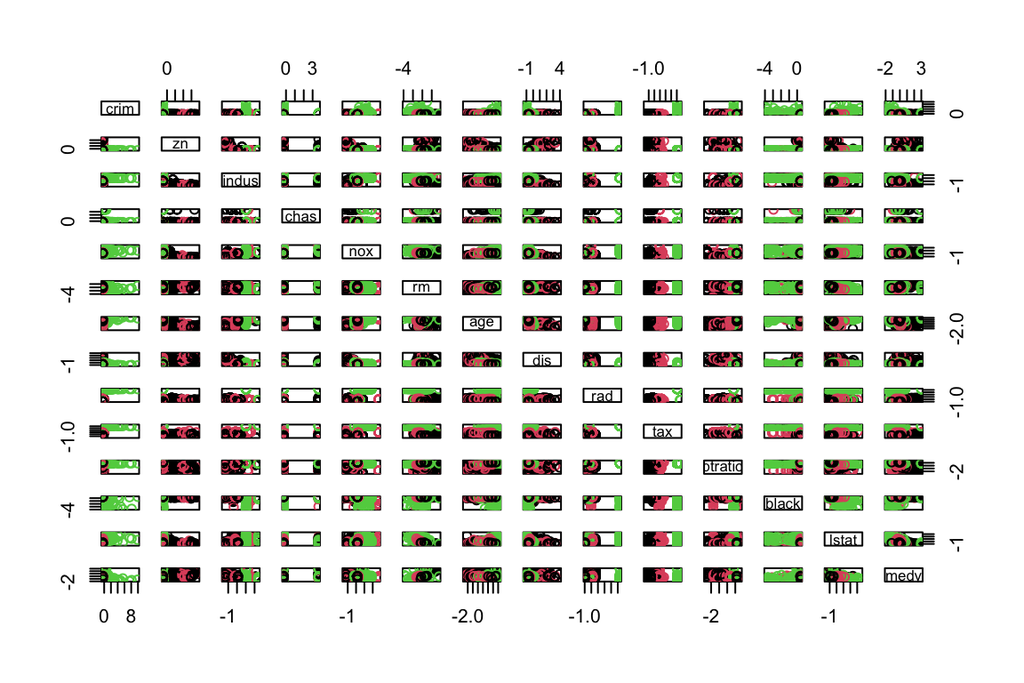

```r
# Use seed to mitigate the effect of random number generators
set.seed(1234)

# k-means clustering
km <- kmeans(Boston, centers = 3)

# plot the scaled data set with clusters
pairs(boston_scaled2, col = km$cluster)
```

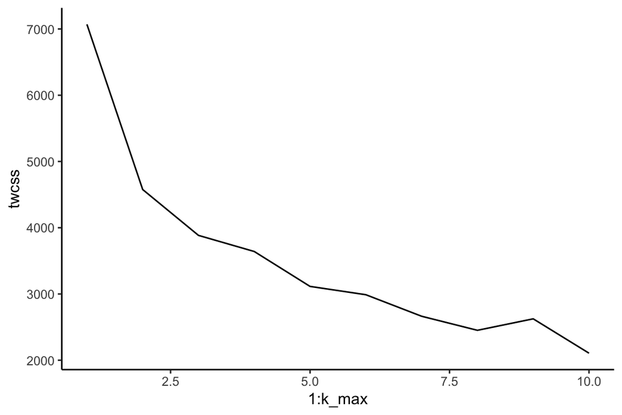

```r
# determine the number of clusters for optimization
k_max <- 10

# calculate the total within sum of squares
twcss <- sapply(1:k_max, function(k){kmeans(boston_scaled2, k)$tot.withinss})

# visualize the results
qplot(x = 1:k_max, y = twcss, geom = 'line')
```

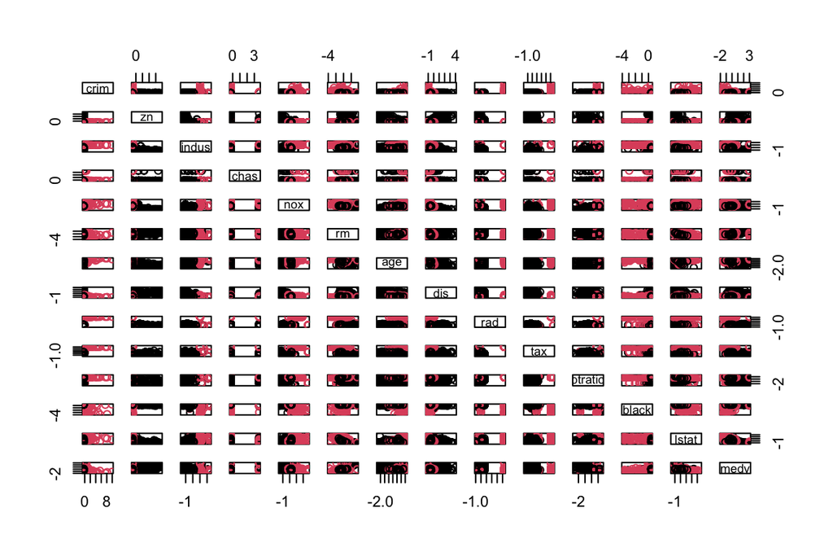

```r
# k-means clustering with optimal number of clusters
km2 <- kmeans(boston_scaled2, centers = 2)

# plot the scaled dataset with clusters
pairs(boston_scaled2, col = km2$cluster)
```

The k-means alorithm was initially done with three clusters. Visualizing how the total of within cluster sum of squares (WCSS) behaves when the number of cluster changes, we can see the total WCSS drops radically at two clusters meaning this is our optimal number of clusters. We then preformed the k-means algorithm again with the optimal number of clusters and visualized it. Looking at our plot with two clusters we can see that overall the clusters are fairly well separated within the variables, meaning the clustering seems to work properly. Comparing the final plot to the original k-mean algorith with 3 clusters we can see that there is more overlap between clusters and is therefore harder to interpret.

(more chapters to be added similarly as we proceed with the course!)